# Part1EDA

```python
import pandas as pd
import numpy as np
import matplotlib.pyplot as plt
import seaborn as sns
```

```python
# Load the dataset
file_path = 'Telco-Customer-Churn.csv'
df = pd.read_csv(file_path)
data = pd.read_csv(file_path)
```

```python
# 1basic display

df.head(10)
```

|  | customerID | gender | SeniorCitizen | Partner | Dependents | tenure | PhoneService | MultipleLines | InternetService | OnlineSecurity | ... | DeviceProtection | TechSupport | StreamingTV | StreamingMovies | Contract | PaperlessBilling | PaymentMethod | MonthlyCharges | TotalCharges | Churn |
| --- | --- | --- | --- | --- | --- | --- | --- | --- | --- | --- | --- | --- | --- | --- | --- | --- | --- | --- | --- | --- | --- |
| 0 | 7590-VHVEG | Female | 0 | Yes | No | 1 | No | No phone service | DSL | No | ... | No | No | No | No | Month-to-month | Yes | Electronic check | 29.85 | 29.85 | No |
| 1 | 5575-GNVDE | Male | 0 | No | No | 34 | Yes | No | DSL | Yes | ... | Yes | No | No | No | One year | No | Mailed check | 56.95 | 1889.5 | No |
| 2 | 3668-QPYBK | Male | 0 | No | No | 2 | Yes | No | DSL | Yes | ... | No | No | No | No | Month-to-month | Yes | Mailed check | 53.85 | 108.15 | Yes |
| 3 | 7795-CFOCW | Male | 0 | No | No | 45 | No | No phone service | DSL | Yes | ... | Yes | Yes | No | No | One year | No | Bank transfer (automatic) | 42.30 | 1840.75 | No |
| 4 | 9237-HQITU | Female | 0 | No | No | 2 | Yes | No | Fiber optic | No | ... | No | No | No | No | Month-to-month | Yes | Electronic check | 70.70 | 151.65 | Yes |
| 5 | 9305-CDSKC | Female | 0 | No | No | 8 | Yes | Yes | Fiber optic | No | ... | Yes | No | Yes | Yes | Month-to-month | Yes | Electronic check | 99.65 | 820.5 | Yes |
| 6 | 1452-KIOVK | Male | 0 | No | Yes | 22 | Yes | Yes | Fiber optic | No | ... | No | No | Yes | No | Month-to-month | Yes | Credit card (automatic) | 89.10 | 1949.4 | No |
| 7 | 6713-OKOMC | Female | 0 | No | No | 10 | No | No phone service | DSL | Yes | ... | No | No | No | No | Month-to-month | No | Mailed check | 29.75 | 301.9 | No |
| 8 | 7892-POOKP | Female | 0 | Yes | No | 28 | Yes | Yes | Fiber optic | No | ... | Yes | Yes | Yes | Yes | Month-to-month | Yes | Electronic check | 104.80 | 3046.05 | Yes |
| 9 | 6388-TABGU | Male | 0 | No | Yes | 62 | Yes | No | DSL | Yes | ... | No | No | No | No | One year | No | Bank transfer (automatic) | 56.15 | 3487.95 | No |

10 rows × 21 columns

```python
# 2 Basic Data Information
print("Basic Information")
print(df.info())
```

```
Basic Information
<class 'pandas.core.frame.DataFrame'>
RangeIndex: 7043 entries, 0 to 7042
Data columns (total 21 columns):
 #   Column            Non-Null Count  Dtype
---  ------            --------------  -----
 0   customerID        7043 non-null   object
 1   gender            7043 non-null   object
 2   SeniorCitizen     7043 non-null   int64
 3   Partner           7043 non-null   object
 4   Dependents        7043 non-null   object
 5   tenure            7043 non-null   int64
 6   PhoneService      7043 non-null   object
 7   MultipleLines     7043 non-null   object
 8   InternetService   7043 non-null   object
 9   OnlineSecurity    7043 non-null   object
 10  OnlineBackup      7043 non-null   object
 11  DeviceProtection  7043 non-null   object
 12  TechSupport       7043 non-null   object
 13  StreamingTV       7043 non-null   object
 14  StreamingMovies   7043 non-null   object
 15  Contract          7043 non-null   object
 16  PaperlessBilling  7043 non-null   object
 17  PaymentMethod     7043 non-null   object
 18  MonthlyCharges    7043 non-null   float64
 19  TotalCharges      7043 non-null   object
 20  Churn             7043 non-null   object
dtypes: float64(1), int64(2), object(18)
memory usage: 1.1+ MB
None
```

# infer :

## TotalCharges need to be numeric .and lets see later on SeniorCitizen , since its just 0 and 1 . let it be or for visluzation object is required

```python
# 3
df.columns
```

```
Index(['customerID', 'gender', 'SeniorCitizen', 'Partner', 'Dependents',
       'tenure', 'PhoneService', 'MultipleLines', 'InternetService',
       'OnlineSecurity', 'OnlineBackup', 'DeviceProtection', 'TechSupport',
       'StreamingTV', 'StreamingMovies', 'Contract', 'PaperlessBilling',
       'PaymentMethod', 'MonthlyCharges', 'TotalCharges', 'Churn'],
      dtype='object')
```

```python
#4
#total charges should be numeric
# Convert 'TotalCharges' from object to numeric (float)
df['TotalCharges'] = pd.to_numeric(df['TotalCharges'], errors='coerce')
```

# infer : there is 21 columns

```python
#5
# Descriptive statistics
print("\nDescriptive statistics:")
print(df.describe())
```

```
Descriptive statistics:
       SeniorCitizen       tenure  MonthlyCharges  TotalCharges
count    7043.000000  7043.000000     7043.000000   7032.000000
mean        0.162147    32.371149       64.761692   2283.300441
std         0.368612    24.559481       30.090047   2266.771362
min         0.000000     0.000000       18.250000     18.800000
25%         0.000000     9.000000       35.500000    401.450000
50%         0.000000    29.000000       70.350000   1397.475000
75%         0.000000    55.000000       89.850000   3794.737500
max         1.000000    72.000000      118.750000   8684.800000
```

# infer :

## Total Charges mean seems to be more or how ??? let us once see the disturbution , outliers and IQR

# 6

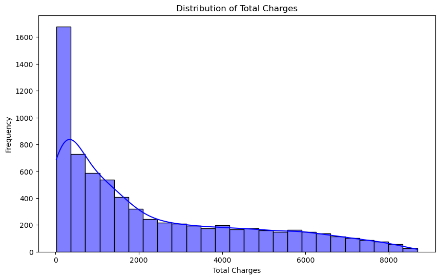

```python
#Visualize the Distribution of 'TotalCharges'

plt.figure(figsize=(10, 6))
sns.histplot(df['TotalCharges'], kde=True, color='blue', edgecolor='k')
plt.title('Distribution of Total Charges')
plt.xlabel('Total Charges')
plt.ylabel('Frequency')
plt.show()
```

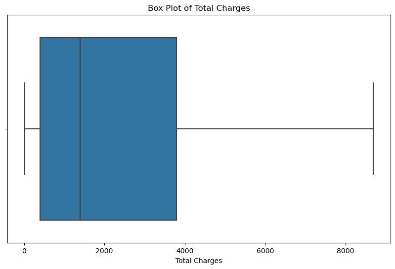

```python
#Boxplot to Identify Outliers
plt.figure(figsize=(10, 6))
sns.boxplot(x=df['TotalCharges'])
plt.title('Box Plot of Total Charges')
plt.xlabel('Total Charges')
plt.show()
```

```python
#Calculate the Interquartile Range (IQR) and Identify Outliers
# Calculate Q1, Q3, and IQR
Q1 = df['TotalCharges'].quantile(0.25)
Q3 = df['TotalCharges'].quantile(0.75)
IQR = Q3 - Q1

# Determine outliers using IQR
lower_bound = Q1 - 1.5 * IQR
upper_bound = Q3 + 1.5 * IQR

print(f"The 25th percentile (Q1) of Total Charges is: {Q1}")
print(f"The 75th percentile (Q3) of Total Charges is: {Q3}")
print(f"The Interquartile Range (IQR) of Total Charges is: {IQR}")
print(f"Values below {lower_bound} and above {upper_bound} could be considered outliers.")
```

```
The 25th percentile (Q1) of Total Charges is: 401.45
The 75th percentile (Q3) of Total Charges is: 3794.7375
The Interquartile Range (IQR) of Total Charges is: 3393.2875000000004
Values below -4688.481250000001 and above 8884.66875 could be considered outliers.
```

# infer on Total Charges

### is The 25th percentile (Q1) of Total Charges is: 401.45

### The 75th percentile (Q3) of Total Charges is: 3794.7375

### he Interquartile Range (IQR) of Total Charges is: 3393.2875000000004

### Values below -4688.481250000001 and above 8884.66875 could be considered outliers.

# 7

# same on MonthlyCharges and tenure side by side

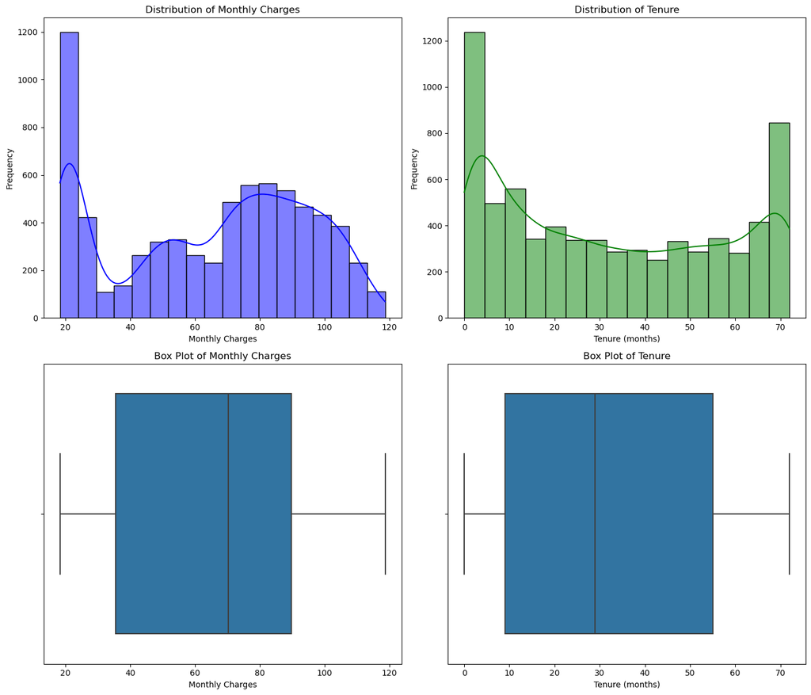

```python
# Visualize the Distribution of Both Variables
fig, ax = plt.subplots(2, 2, figsize=(14, 12))

# Histogram and KDE for MonthlyCharges
sns.histplot(df['MonthlyCharges'], kde=True, color='blue', ax=ax[0, 0])
ax[0, 0].set_title('Distribution of Monthly Charges')
ax[0, 0].set_xlabel('Monthly Charges')
ax[0, 0].set_ylabel('Frequency')

# Histogram and KDE for tenure
sns.histplot(df['tenure'], kde=True, color='green', ax=ax[0, 1])
ax[0, 1].set_title('Distribution of Tenure')
ax[0, 1].set_xlabel('Tenure (months)')
ax[0, 1].set_ylabel('Frequency')

# Boxplot for MonthlyCharges
sns.boxplot(x=df['MonthlyCharges'], ax=ax[1, 0])
ax[1, 0].set_title('Box Plot of Monthly Charges')
ax[1, 0].set_xlabel('Monthly Charges')

# Boxplot for tenure
sns.boxplot(x=df['tenure'], ax=ax[1, 1])
ax[1, 1].set_title('Box Plot of Tenure')
ax[1, 1].set_xlabel('Tenure (months)')

plt.tight_layout()
plt.show()
```

```python
#Calculate the IQR for Both Variables and Identify Outliers
# Calculate IQR for MonthlyCharges
Q1_MC = df['MonthlyCharges'].quantile(0.25)
Q3_MC = df['MonthlyCharges'].quantile(0.75)
IQR_MC = Q3_MC - Q1_MC

# Calculate IQR for tenure
Q1_tenure = df['tenure'].quantile(0.25)
Q3_tenure = df['tenure'].quantile(0.75)
IQR_tenure = Q3_tenure - Q1_tenure

# Determine outliers using IQR for both fields
lower_bound_MC = Q1_MC - 1.5 * IQR_MC
upper_bound_MC = Q3_MC + 1.5 * IQR_MC
lower_bound_tenure = Q1_tenure - 1.5 * IQR_tenure
upper_bound_tenure = Q3_tenure + 1.5 * IQR_tenure

print(f"Monthly Charges - 25th percentile (Q1): {Q1_MC}, 75th percentile (Q3): {Q3_MC}, IQR: {IQR_MC}")
print(f"Monthly Charges outliers are values below {lower_bound_MC} and above {upper_bound_MC}.")
print(f"Tenure - 25th percentile (Q1): {Q1_tenure}, 75th percentile (Q3): {Q3_tenure}, IQR: {IQR_tenure}")
print(f"Tenure outliers are values below {lower_bound_tenure} and above {upper_bound_tenure}.")
```

```
Monthly Charges - 25th percentile (Q1): 35.5, 75th percentile (Q3): 89.85, IQR: 54.349999999999994
Monthly Charges outliers are values below -46.02499999999999 and above 171.375.
Tenure - 25th percentile (Q1): 9.0, 75th percentile (Q3): 55.0, IQR: 46.0
Tenure outliers are values below -60.0 and above 124.0.
```

## Monthly Charges outliers are values below -46.02499999999999 and above 171.375.

## Tenure outliers are values below -60.0 and above 124.0.

# Conclusion , for our nominal values , outliers , not present , so our ML models will not disrupt too much or give more errors

# 8

### Let us analyze the categorical columns, count of its sub cat

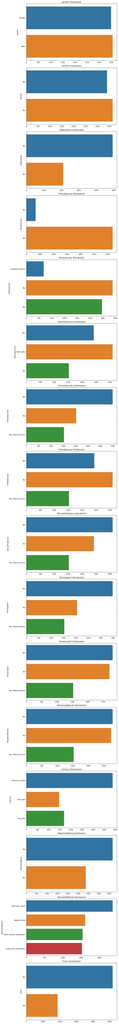

```python
# Count plots for categorical data
categorical_columns = df.select_dtypes(include=['object']).columns
fig, ax = plt.subplots(len(categorical_columns) - 1, 1, figsize=(10, 5 * len(categorical_columns)))
for i, column in enumerate([col for col in categorical_columns if col != 'customerID']):
    sns.countplot(y=column, data=df, ax=ax[i])
    ax[i].set_title(f'{column} Distribution')
    ax[i].set_xlabel('')
plt.tight_layout()
plt.show()
```

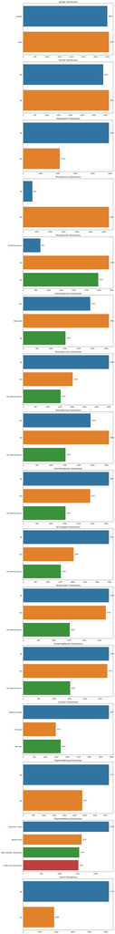

```python
# detailed vaules of categorical columns

# Identify categorical columns excluding 'customerID'
categorical_columns = df.select_dtypes(include=['object']).columns
categorical_columns = [col for col in categorical_columns if col != 'customerID']

# Create figure with appropriate size based on the number of categorical columns
fig, ax = plt.subplots(len(categorical_columns), 1, figsize=(10, 5 * len(categorical_columns)))

# Iterate through the list of categorical columns to create count plots
for i, column in enumerate(categorical_columns):
    # Create countplot
    sns.countplot(y=column, data=df, ax=ax[i] if len(categorical_columns) > 1 else ax)
    ax_temp = ax[i] if len(categorical_columns) > 1 else ax

    # Set title and labels
    ax_temp.set_title(f'{column} Distribution')
    ax_temp.set_xlabel('')
    ax_temp.set_ylabel('')

    # Add value labels next to each bar
    for p in ax_temp.patches:
        ax_temp.annotate(f"{int(p.get_width())}",  # Extract count
                   (p.get_x() + p.get_width(), p.get_y() + p.get_height()/2),  # Position for label
                   xytext=(5, 0),  # Distance from bar
                   textcoords='offset points',
                   va='center',  # Center vertically in bar
                   ha='left')  # Align text left

# Adjust layout to not overlap graphs
plt.tight_layout()
plt.show()
```

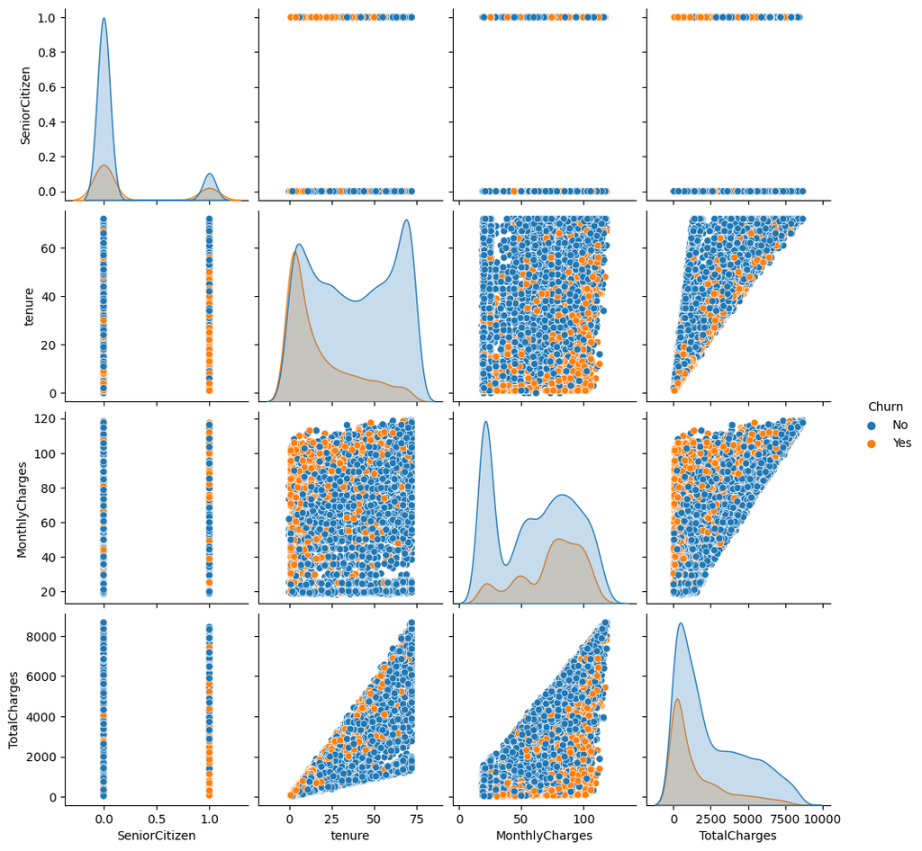

```python
#9 multi numerical pari plot

# Pairplot for numeric variables
sns.pairplot(df, hue='Churn')
plt.show()
```

# 10

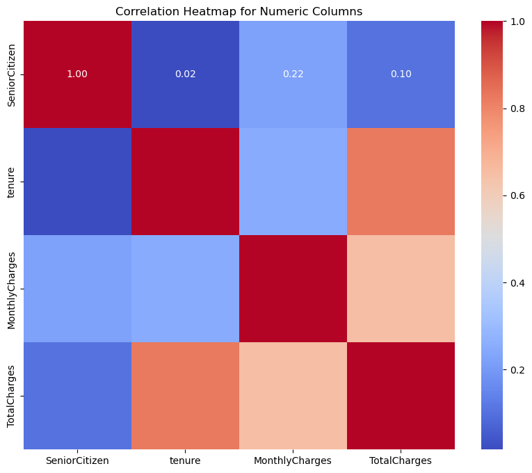

```python
#let us test heat corelation

import matplotlib.pyplot as plt
import seaborn as sns

# Select only numeric columns from the DataFrame
numeric_df = df.select_dtypes(include=['float64', 'int64'])

# Calculate the correlation matrix for the numeric columns
corr_matrix = numeric_df.corr()

# Plot the correlation heatmap
plt.figure(figsize=(10, 8))
sns.heatmap(corr_matrix, annot=True, fmt=".2f", cmap='coolwarm')
plt.title('Correlation Heatmap for Numeric Columns')
plt.show()
```

# 11

```python
#Detecting Missing Values
# Check for missing values
missing_values = df.isnull().sum()
print("Missing values in each column:\n", missing_values)
```

```
Missing values in each column:
 customerID           0
gender               0
SeniorCitizen        0
Partner              0
Dependents           0
tenure               0
PhoneService         0
MultipleLines        0
InternetService      0
OnlineSecurity       0
OnlineBackup         0
DeviceProtection     0
TechSupport          0
StreamingTV          0
StreamingMovies      0
Contract             0
PaperlessBilling     0
PaymentMethod        0
MonthlyCharges       0
TotalCharges        11
Churn                0
dtype: int64
```

```python
#Handling Missing Values
# Fill missing values with the median or mean
df['TotalCharges'] = df['TotalCharges'].fillna(df['TotalCharges'].median())

# Or drop rows with missing values
#df.dropna(inplace=True)

# Or drop columns with a high percentage of missing values
#threshold = 0.4  # Example threshold
#df.dropna(axis=1, thresh=int(threshold * len(df)), inplace=True)
```

```python
#Detecting Missing Values
# Check for missing values
missing_values = df.isnull().sum()
print("Missing values in each column:\n", missing_values)
```

```
Missing values in each column:
 customerID          0
gender              0
SeniorCitizen       0
Partner             0
Dependents          0
tenure              0
PhoneService        0
MultipleLines       0
InternetService     0
OnlineSecurity      0
OnlineBackup        0
DeviceProtection    0
TechSupport         0
StreamingTV         0
StreamingMovies     0
Contract            0
PaperlessBilling    0
PaymentMethod       0
MonthlyCharges      0
TotalCharges        0
Churn               0
dtype: int64
```

# 12

```python
#Detecting and Removing Duplicates
# Print the number of duplicate rows
print("Number of duplicate rows:", df.duplicated().sum())

# Remove duplicate rows
df.drop_duplicates(inplace=True)
```

```
Number of duplicate rows: 0
```

```python
# Convert data types
#df['column_name'] = pd.to_numeric(df['column_name'], errors='coerce')
#df['date_column'] = pd.to_datetime(df['date_column'])

# Simple outlier detection based on IQR
#Q1 = df['numeric_column'].quantile(0.25)
#Q3 = df['numeric_column'].quantile(0.75)
#IQR = Q3 - Q1
#lower_bound = Q1 - 1.5 * IQR
#upper_bound = Q3 + 1.5 * IQR

# Filter out outliers
#df_filtered = df[(df['numeric_column'] >= lower_bound) & (df['numeric_column'] <= upper_bound)]
```

# 13 - saving the dataset here

```python
df.to_csv('D01Pre_processed_telco_data.csv', index=False)
```

# 14 -

# Dummy Variables:

Converts all categorical variables into dummy/indicator variables using pd.get_dummies. It automatically handles all categorical columns except the 'customerID' to avoid unnecessary expansion. drop_first=True is used to avoid multicollinearity by dropping the first category in each feature. Scaling:

Uses StandardScaler from sklearn.preprocessing to standardize the numerical columns ('tenure', 'MonthlyCharges', 'TotalCharges') by removing the mean and scaling to unit variance. Check Processed Data:

Displays the first few rows of the processed dataset. Prints detailed information about the new DataFrame, including data types and the presence of any null values. Save Processed Data:

Saves the fully processed data to a CSV file, ensuring that all transformations are preserved for future analysis or model training.

```python
from sklearn.preprocessing import StandardScaler

# Convert categorical variables to dummy/indicator variables
categorical_columns = df.select_dtypes(include=['object']).columns.drop('customerID')  # Exclude 'customerID'
df_encoded = pd.get_dummies(df, columns=categorical_columns, drop_first=True)  # Create dummies and drop the first to avoid dummy trap

# Scaling numerical features
scaler = StandardScaler()
numerical_columns = ['tenure', 'MonthlyCharges', 'TotalCharges']
df_encoded[numerical_columns] = scaler.fit_transform(df_encoded[numerical_columns])

# Check the processed data
print("Processed Data:")
print(df_encoded.head())
print("\n")

# Summary of the new dataframe
print("New DataFrame Information:")
print(df_encoded.info())
print("\n")

# Save the fully processed DataFrame for further analysis
df_encoded.to_csv('D02fully_processed_telco_data.csv', index=False)
```

```
Processed Data:
   customerID  SeniorCitizen    tenure  MonthlyCharges  TotalCharges  \
0  7590-VHVEG              0 -1.277445       -1.160323     -0.994242
1  5575-GNVDE              0  0.066327       -0.259629     -0.173244
2  3668-QPYBK              0 -1.236724       -0.362660     -0.959674
3  7795-CFOCW              0  0.514251       -0.746535     -0.194766
4  9237-HQITU              0 -1.236724        0.197365     -0.940470

   gender_Male  Partner_Yes  Dependents_Yes  PhoneService_Yes  \
0        False         True           False             False
1         True        False           False              True
2         True        False           False              True
3         True        False           False             False
4        False        False           False              True

```

[output cut: 79 more lines]

```python
df_encoded.head(10)
```

|  | customerID | SeniorCitizen | tenure | MonthlyCharges | TotalCharges | gender_Male | Partner_Yes | Dependents_Yes | PhoneService_Yes | MultipleLines_No phone service | ... | StreamingTV_Yes | StreamingMovies_No internet service | StreamingMovies_Yes | Contract_One year | Contract_Two year | PaperlessBilling_Yes | PaymentMethod_Credit card (automatic) | PaymentMethod_Electronic check | PaymentMethod_Mailed check | Churn_Yes |
| --- | --- | --- | --- | --- | --- | --- | --- | --- | --- | --- | --- | --- | --- | --- | --- | --- | --- | --- | --- | --- | --- |
| 0 | 7590-VHVEG | 0 | -1.277445 | -1.160323 | -0.994242 | False | True | False | False | True | ... | False | False | False | False | False | True | False | True | False | False |
| 1 | 5575-GNVDE | 0 | 0.066327 | -0.259629 | -0.173244 | True | False | False | True | False | ... | False | False | False | True | False | False | False | False | True | False |
| 2 | 3668-QPYBK | 0 | -1.236724 | -0.362660 | -0.959674 | True | False | False | True | False | ... | False | False | False | False | False | True | False | False | True | True |
| 3 | 7795-CFOCW | 0 | 0.514251 | -0.746535 | -0.194766 | True | False | False | False | True | ... | False | False | False | True | False | False | False | False | False | False |
| 4 | 9237-HQITU | 0 | -1.236724 | 0.197365 | -0.940470 | False | False | False | True | False | ... | False | False | False | False | False | True | False | True | False | True |
| 5 | 9305-CDSKC | 0 | -0.992402 | 1.159546 | -0.645186 | False | False | False | True | False | ... | True | False | True | False | False | True | False | True | False | True |
| 6 | 1452-KIOVK | 0 | -0.422317 | 0.808907 | -0.146799 | True | False | True | True | False | ... | True | False | False | False | False | True | True | False | False | False |
| 7 | 6713-OKOMC | 0 | -0.910961 | -1.163647 | -0.874137 | False | False | False | False | True | ... | False | False | False | False | False | False | False | False | True | False |
| 8 | 7892-POOKP | 0 | -0.177995 | 1.330711 | 0.337349 | False | True | False | True | False | ... | True | False | True | False | False | True | False | True | False | True |
| 9 | 6388-TABGU | 0 | 1.206498 | -0.286218 | 0.532439 | True | False | True | True | False | ... | False | False | False | True | False | False | False | False | False | False |

10 rows × 32 columns

# or one hot encoding and than normalziation also

```python
import pandas as pd
from sklearn.preprocessing import MinMaxScaler, OneHotEncoder
from sklearn.impute import SimpleImputer
from sklearn.compose import ColumnTransformer
from sklearn.pipeline import Pipeline

# Create a ColumnTransformer to apply transformations to the respective column types
preprocessor = ColumnTransformer(
    transformers=[
        ('num', MinMaxScaler(), numerical_columns),
        ('cat', OneHotEncoder(drop='first'), categorical_columns)
    ])

# Apply transformations
df_processed = preprocessor.fit_transform(df)

# Generate new column names for the transformed features
new_categorical_features = preprocessor.named_transformers_['cat'].get_feature_names_out(categorical_columns)
new_column_names = numerical_columns + list(new_categorical_features)

# Convert the processed numpy array back to a DataFrame
df_processed = pd.DataFrame(df_processed, columns=new_column_names)

# Check the processed data
print("Processed Data:")
print(df_processed.head())
print("\n")

# Summary of the new dataframe
print("New DataFrame Information:")
print(df_processed.info())
print("\n")

# Save the fully processed DataFrame for further analysis
df_processed.to_csv('D03Mainfully_processed_telco_data.csv', index=False)

print("Data preprocessing complete and saved to 'D03Mainfully_processed_telco_data.csv'.")
```

```
Processed Data:
     tenure  MonthlyCharges  TotalCharges  gender_Male  Partner_Yes  \
0  0.013889        0.115423      0.001275          0.0          1.0
1  0.472222        0.385075      0.215867          1.0          0.0
2  0.027778        0.354229      0.010310          1.0          0.0
3  0.625000        0.239303      0.210241          1.0          0.0
4  0.027778        0.521891      0.015330          0.0          0.0

   Dependents_Yes  PhoneService_Yes  MultipleLines_No phone service  \
0             0.0               0.0                             1.0
1             0.0               1.0                             0.0
2             0.0               1.0                             0.0
3             0.0               0.0                             1.0
4             0.0               1.0                             0.0

   MultipleLines_Yes  InternetService_Fiber optic  ...  StreamingTV_Yes  \
0                0.0                          0.0  ...              0.0
1                0.0                          0.0  ...              0.0
2                0.0                          0.0  ...              0.0
3                0.0                          0.0  ...              0.0
4                0.0                          1.0  ...              0.0

   StreamingMovies_No internet service  StreamingMovies_Yes  \
0                                  0.0                  0.0
1                                  0.0                  0.0
2                                  0.0                  0.0
3                                  0.0                  0.0
4                                  0.0                  0.0

   Contract_One year  Contract_Two year  PaperlessBilling_Yes  \
0                0.0                0.0                   1.0
1                1.0                0.0                   0.0
2                0.0                0.0                   1.0
3                1.0                0.0                   0.0
4                0.0                0.0                   1.0

   PaymentMethod_Credit card (automatic)  PaymentMethod_Electronic check  \
0                                    0.0                             1.0
1                                    0.0                             0.0
2                                    0.0                             0.0
```

[output cut: 40 more lines]

```
 21  StreamingMovies_No internet service    7043 non-null   float64
 22  StreamingMovies_Yes                    7043 non-null   float64
 23  Contract_One year                      7043 non-null   float64
 24  Contract_Two year                      7043 non-null   float64
 25  PaperlessBilling_Yes                   7043 non-null   float64
 26  PaymentMethod_Credit card (automatic)  7043 non-null   float64
 27  PaymentMethod_Electronic check         7043 non-null   float64
 28  PaymentMethod_Mailed check             7043 non-null   float64
 29  Churn_Yes                              7043 non-null   float64
dtypes: float64(30)
memory usage: 1.6 MB
None


Data preprocessing complete and saved to 'D03Mainfully_processed_telco_data.csv'.
```